# task

```python
import pandas as pd
import numpy as np
```

```python
df = pd.read_csv("df_task_final.csv", delimiter=",", engine="python")
df
```

|  | Timestamp | P1 | T1 | T2 | Ta1 | Ta3 | Ta4 | Ta5 | Ta6 | Ta7 | Ta8 | Ta_q | v_1 | power |
| --- | --- | --- | --- | --- | --- | --- | --- | --- | --- | --- | --- | --- | --- | --- |
| 0 | 2004-02-10 00:00:00 | -262.572912 | 611.95100 | 598.11930 | 181.534245 | 155.791908 | 183,5510776 | 168.972999 | 187.873896 | 191.665459 | 192.628790 | 389.347742 | low | -275.511342 |
| 1 | 2004-02-10 00:01:00 | -262.502827 | 611.60874 | 597.32802 | 182.118922 | 155.203158 | 184,3680832 | 169.471913 | 188.462358 | 192.330486 | 193.248012 | 414.523798 | low | -275.519129 |
| 2 | 2004-02-10 00:02:00 | -262.432774 | 611.26648 | 596.53674 | 183.047085 | 153.407394 | 185,1172925 | 170.123189 | 189.107933 | 193.000879 | 194.033012 | 396.883613 | low | -275.521336 |
| 3 | 2004-02-10 00:03:00 | -262.362689 | 610.92736 | 595.74860 | 183.826767 | 154.870932 | 186,0627518 | 171.123891 | 190.142222 | 193.977434 | 194.888348 | 383.059752 | low | -275.521336 |
| 4 | 2004-02-10 00:04:00 | -262.292604 | 610.58510 | 594.95732 | 184.579713 | 156.397284 | 186,6565326 | 171.687200 | 190.586563 | 194.514055 | 195.600808 | 386.056265 | low | -275.521336 |
| ... | ... | ... | ... | ... | ... | ... | ... | ... | ... | ... | ... | ... | ... | ... |
| 30236 | 2004-03-01 23:56:00 | -187.017918 | 1508.63138 | 1510.05066 | 923.168960 | -274.000000 | 962,2494 | 910.926100 | 966.158700 | 986.976900 | 988.107300 | 386.676779 | S | 503.300720 |
| 30237 | 2004-03-01 23:57:00 | -185.078968 | 1511.67404 | 1512.90178 | 920.361800 | -274.000000 | 963,10348 | 914.430340 | 969.465120 | 991.121700 | 991.884720 | 366.613660 | S | 519.970980 |
| 30238 | 2004-03-01 23:58:00 | -183.139704 | 1517.25068 | 1517.97288 | 920.619280 | -274.000000 | 968,44148 | 919.532840 | 973.927060 | 996.035800 | 996.732880 | 361.511926 | S | 537.774780 |
| 30239 | 2004-03-01 23:59:00 | -181.200754 | 1522.82418 | 1523.04084 | 921.479640 | -274.000000 | 974,74974 | 924.977600 | 978.238280 | 1000.833720 | 1001.621860 | 369.799603 | S | 556.925640 |
| 30240 | 2004-03-02 00:00:00 | -179.252698 | 1528.40082 | 1528.11194 | 924.773500 | -274.000000 | 980,48338 | 929.317080 | 982.003140 | 1005.135520 | 1006.482580 | 367.893458 | S | 583.424100 |

30241 rows × 14 columns

```python
df.info()
```

```
<class 'pandas.core.frame.DataFrame'>
RangeIndex: 30241 entries, 0 to 30240
Data columns (total 14 columns):
 #   Column     Non-Null Count  Dtype
---  ------     --------------  -----
 0   Timestamp  30241 non-null  object
 1   P1         30231 non-null  float64
 2   T1         30219 non-null  float64
 3   T2         30241 non-null  float64
 4   Ta1        30132 non-null  float64
 5   Ta3        30171 non-null  float64
 6   Ta4        30129 non-null  object
 7   Ta5        30168 non-null  float64
 8   Ta6        30157 non-null  float64
 9   Ta7        30168 non-null  float64
 10  Ta8        30168 non-null  float64
 11  Ta_q       30169 non-null  float64
 12  v_1        30241 non-null  object
 13  power      30241 non-null  float64
dtypes: float64(11), object(3)
memory usage: 3.2+ MB
```

```python
df.v_1.value_counts()
```

```
M      22905
S       4891
L       1962
low      483
Name: v_1, dtype: int64
```

```python
df.Ta4
```

```
0        183,5510776
1        184,3680832
2        185,1172925
3        186,0627518
4        186,6565326
            ...
30236       962,2494
30237      963,10348
30238      968,44148
30239      974,74974
30240      980,48338
Name: Ta4, Length: 30241, dtype: object
```

#### All attributes are numerical, except the v_1 field (Ta4 field has only incorrect decimal separator, which I will take care in next line).

```python
df.Ta4 = df.Ta4.replace(",", ".", regex=True).astype(float)
```

#### Let’s look at the other fields. The describe() method shows a summary of the numerical attributes.

```python
df.describe()
```

|  | P1 | T1 | T2 | Ta1 | Ta3 | Ta4 | Ta5 | Ta6 | Ta7 | Ta8 | Ta_q | power |
| --- | --- | --- | --- | --- | --- | --- | --- | --- | --- | --- | --- | --- |
| count | 30231.000000 | 30219.000000 | 30241.000000 | 30132.000000 | 30171.000000 | 30129.000000 | 30168.000000 | 30157.000000 | 30168.000000 | 30168.000000 | 30169.000000 | 30241.000000 |
| mean | -145.508880 | 1527.588187 | 1527.133659 | 982.886298 | 781.369002 | 1033.667336 | 968.200036 | 1006.890481 | 1042.791981 | 1047.313660 | 387.214772 | 887.202106 |
| std | 27.085915 | 122.844911 | 124.735997 | 83.982212 | 496.127352 | 93.348912 | 87.296461 | 90.686632 | 94.075705 | 94.474558 | 17.942195 | 278.178419 |
| min | -274.000000 | -110.862870 | -274.000000 | 181.534245 | -274.000000 | 183.551078 | 168.972999 | 187.873896 | 191.665459 | 192.628790 | 304.668752 | -275.596991 |
| 25% | -154.417653 | 1544.319050 | 1544.056860 | 985.318954 | 893.381530 | 1036.327040 | 970.444871 | 1009.863380 | 1046.007350 | 1050.659639 | 378.854131 | 815.448120 |
| 50% | -136.172526 | 1551.360500 | 1551.128140 | 1003.243992 | 1029.130760 | 1055.049942 | 987.941021 | 1027.707756 | 1064.701148 | 1069.277540 | 390.051792 | 982.555780 |
| 75% | -126.046183 | 1553.505120 | 1553.348120 | 1013.962254 | 1051.123936 | 1070.376511 | 1001.758197 | 1039.923580 | 1077.883048 | 1082.633536 | 399.329667 | 1075.681900 |
| max | -120.431392 | 1561.094500 | 1560.400560 | 1049.356488 | 1106.053860 | 1112.636285 | 1042.309980 | 1079.600620 | 1116.866140 | 1119.095540 | 434.849707 | 1120.998380 |

#### Another quick way to get a feel of the type of data you are dealing with is to plot a histogram for each numerical attribute.

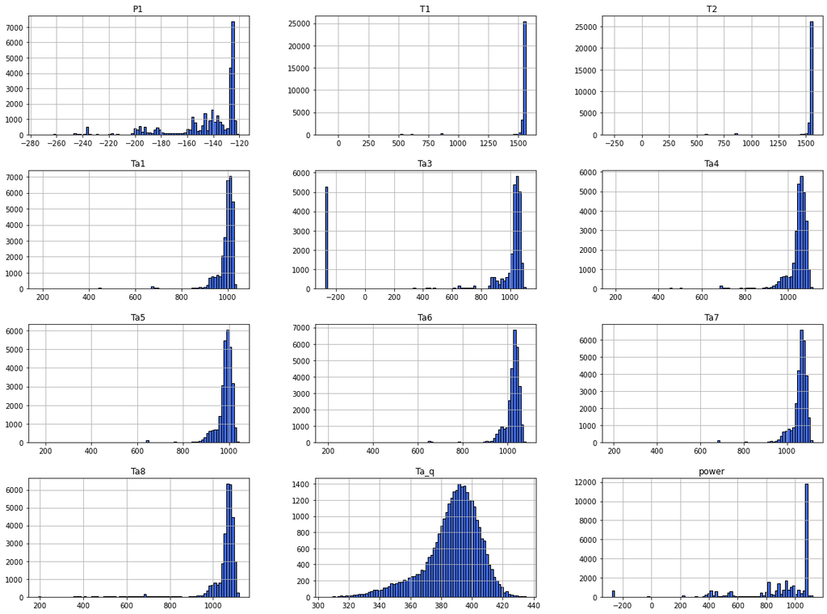

```python
%matplotlib inline
import matplotlib.pyplot as plt

df.hist(bins=80, figsize=(20,15), color="royalblue", edgecolor="black")
plt.show()
```

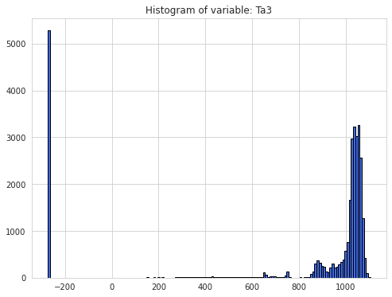

```python
import seaborn as sns

sns.set_style("whitegrid")
fig, ax = plt.subplots(figsize=(8,6))
plt.title("Histogram of variable: Ta3")
plt.hist(df.Ta3.tolist(),  bins=150, color="royalblue", edgecolor="black")
plt.show()
```

#### The Ta3 feature is capped, the system can be evaluated poorly when taking into consideration values beyond -250.

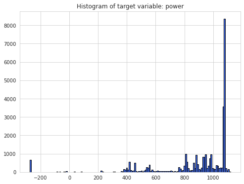

```python
sns.set_style("whitegrid")
fig, ax = plt.subplots(figsize=(8,6))
plt.title("Histogram of target variable: power")
plt.hist(df.power.tolist(),  bins=150, color="royalblue", edgecolor="black")
plt.show()
```

#### The target variable is not capped, like I thought before.

#### Function for calculating moving average.

```python
def moving_avg(df, window):
    for col in df.columns:
        df[f"{col}__window__mean"] = df[col].rolling(window=window).mean()
    df = df.dropna().reset_index(drop=True)
    return df
```

```python
df_moving_avg = df.drop(columns=["v_1", "Timestamp"])
df_moving_avg = moving_avg(df_moving_avg, 20)
df_moving_avg
```

|  | P1 | T1 | T2 | Ta1 | Ta3 | Ta4 | Ta5 | Ta6 | Ta7 | Ta8 | ... | T2__window__mean | Ta1__window__mean | Ta3__window__mean | Ta4__window__mean | Ta5__window__mean | Ta6__window__mean | Ta7__window__mean | Ta8__window__mean | Ta_q__window__mean | power__window__mean |
| --- | --- | --- | --- | --- | --- | --- | --- | --- | --- | --- | --- | --- | --- | --- | --- | --- | --- | --- | --- | --- | --- |
| 0 | -261.863555 | 606.51566 | 592.77188 | 193.807871 | 182.551908 | 201.206343 | 185.010831 | 205.018940 | 209.091511 | 210.026908 | ... | 593.235658 | 186.540047 | 165.314170 | 191.088443 | 175.791580 | 195.231898 | 199.067122 | 199.996150 | 392.393162 | -275.507592 |
| 1 | -261.656880 | 606.42460 | 592.80014 | 195.045981 | 184.419925 | 202.387293 | 186.212862 | 206.645141 | 210.706117 | 211.154483 | ... | 592.969700 | 187.215634 | 166.745571 | 192.030254 | 176.653573 | 196.170460 | 200.019155 | 200.922434 | 392.348776 | -275.504699 |
| 2 | -261.450236 | 606.33354 | 592.80014 | 196.611285 | 185.482147 | 203.824766 | 187.493949 | 208.227072 | 212.473900 | 213.282761 | ... | 592.743306 | 187.940252 | 168.259520 | 193.003088 | 177.554675 | 197.158696 | 201.026326 | 201.924172 | 391.215893 | -275.501026 |
| 3 | -261.243562 | 606.24562 | 592.80014 | 199.018701 | 187.794457 | 205.496533 | 189.414382 | 210.146259 | 214.220075 | 215.157054 | ... | 592.556476 | 188.738833 | 169.978874 | 194.022050 | 178.519234 | 198.210612 | 202.087285 | 202.980374 | 389.866784 | -275.497412 |
| 4 | -261.035034 | 606.15456 | 592.80014 | 201.043057 | 189.653322 | 207.405035 | 191.537006 | 212.258821 | 216.412747 | 217.001162 | ... | 592.409053 | 189.599648 | 171.717993 | 195.089164 | 179.539890 | 199.316442 | 203.209051 | 204.086014 | 389.843403 | -275.494187 |
| ... | ... | ... | ... | ... | ... | ... | ... | ... | ... | ... | ... | ... | ... | ... | ... | ... | ... | ... | ... | ... | ... |
| 29438 | -187.017918 | 1508.63138 | 1510.05066 | 923.168960 | -274.000000 | 962.249400 | 910.926100 | 966.158700 | 986.976900 | 988.107300 | ... | 1502.965250 | 928.737593 | -274.000000 | 959.083966 | 908.610507 | 962.931251 | 983.808954 | 986.254857 | 359.337389 | 457.181813 |
| 29439 | -185.078968 | 1511.67404 | 1512.90178 | 920.361800 | -274.000000 | 963.103480 | 914.430340 | 969.465120 | 991.121700 | 991.884720 | ... | 1503.140619 | 927.588039 | -274.000000 | 958.829469 | 908.494484 | 962.854007 | 983.745212 | 986.072737 | 360.114242 | 460.538473 |
| 29440 | -183.139704 | 1517.25068 | 1517.97288 | 920.619280 | -274.000000 | 968.441480 | 919.532840 | 973.927060 | 996.035800 | 996.732880 | ... | 1503.653852 | 926.581512 | -274.000000 | 959.027760 | 908.824812 | 963.203960 | 984.108667 | 986.346388 | 359.567112 | 464.805576 |
| 29441 | -181.200754 | 1522.82418 | 1523.04084 | 921.479640 | -274.000000 | 974.749740 | 924.977600 | 978.238280 | 1000.833720 | 1001.621860 | ... | 1504.504792 | 925.781597 | -274.000000 | 959.693440 | 909.561456 | 963.909832 | 984.884404 | 987.030123 | 359.815361 | 470.050475 |
| 29442 | -179.252698 | 1528.40082 | 1528.11194 | 924.773500 | -274.000000 | 980.483380 | 929.317080 | 982.003140 | 1005.135520 | 1006.482580 | ... | 1505.693753 | 925.327867 | -274.000000 | 960.798877 | 910.675528 | 964.977589 | 986.062061 | 988.133362 | 360.205238 | 476.640550 |

29443 rows × 24 columns

#### Plotted example of moving average on power feature.

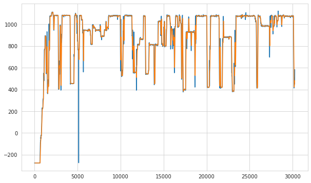

```python
df.power.plot(figsize=(10,6))
df.power.rolling(window=50).mean().plot()
plt.show() # orange line plotted below, is our moving average line.
```

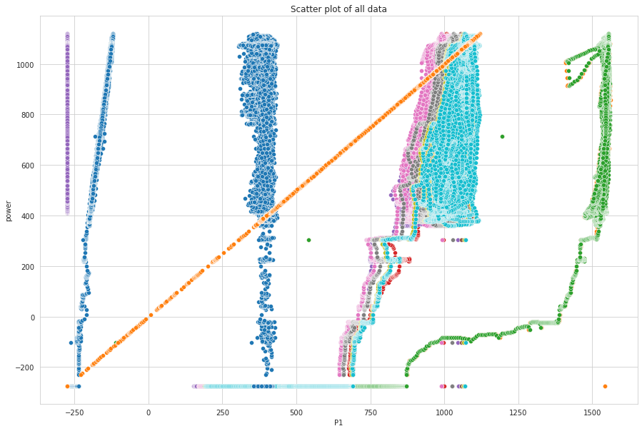

```python
df_to_plot = df.drop(columns=["v_1", "Timestamp"])
df_to_plot

fig, ax = plt.subplots(figsize=(15,10))
plt.title("Scatter plot of all data")
for each in df_to_plot.columns:
    sns.scatterplot(data=df_to_plot, x=df_to_plot[each], y=df_to_plot.power)
```

#### Scatter plot above clearly shows that some of the features are highly correlated with each other, which I will take care later.

#### Heatmap will show correlation between numerical attributes against every other.

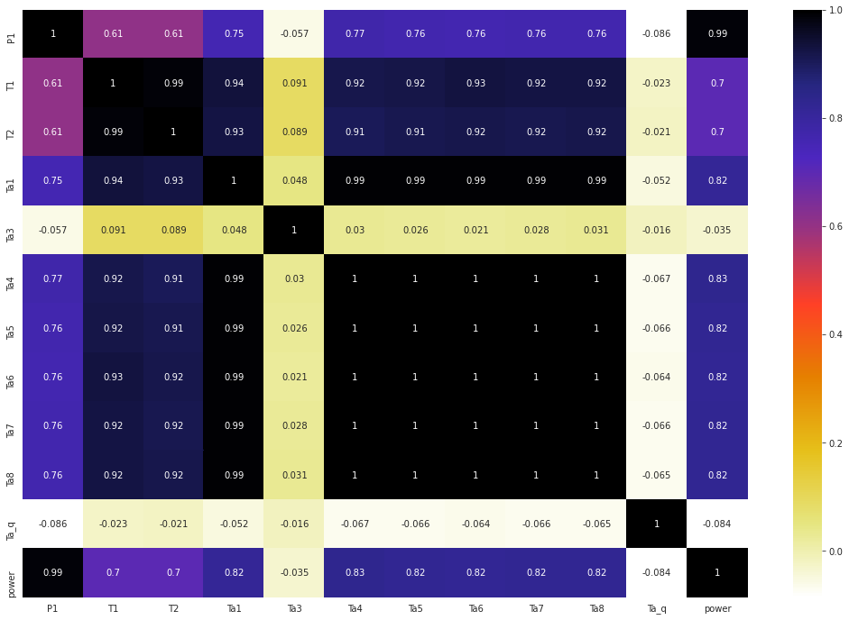

```
(12, 12)
```

```python
plt.figure(figsize=(18,12))
corr_matrix = df.corr() # method: pearson
sns.heatmap(corr_matrix, annot=True, cmap=plt.cm.CMRmap_r)
plt.show()
print(corr_matrix.shape)
```

#### Featureas Ta4, Ta5, Ta6, Ta7, Ta8 and Ta1 are representing almost the same information. As well as T1 and T2.

#### Now, I will deal with variable Ta3. I decided to remove rows which were capped.

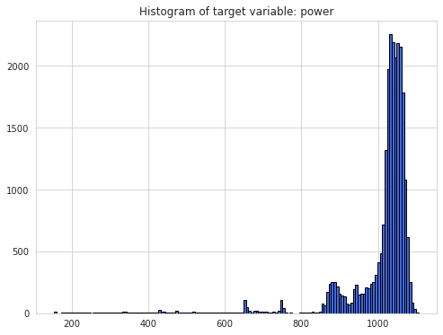

```
18.27% of rows were dropped.
```

```python
new_df = df.where(df.Ta3 > -250).dropna().reset_index(drop=True)
new_df

sns.set_style("whitegrid")
fig, ax = plt.subplots(figsize=(8,6))
plt.title("Histogram of target variable: power")
plt.hist(new_df.Ta3.tolist(),  bins=150, color="royalblue", edgecolor="black")
plt.show()
print(f"{round((1 - len(new_df.index)/len(df.index))*100, 3)}% of rows were dropped.")
```

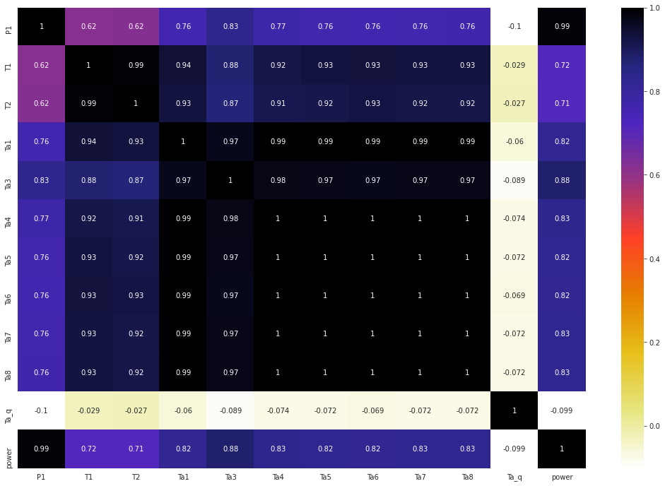

```
(12, 12)
```

```python
plt.figure(figsize=(18,12))
corr_matrix = new_df.corr() # method: pearson
sns.heatmap(corr_matrix, annot=True, cmap=plt.cm.CMRmap_r)
plt.show()
print(corr_matrix.shape)
```

#### After removing capped values, the Ta3 feature becomes also correlated with Ta4, Ta5, Ta6, Ta7, Ta8 and Ta1. We will not take into model the Ta3 variable.

#### Feature selection:

```python
corr_matrix = new_df.drop(columns="power").corr() # method: pearson
sorted_matrix = corr_matrix.unstack().sort_values(ascending=False)

keys = []
values = []
for key, value in zip(sorted_matrix.keys(), sorted_matrix.values):
    keys.append(key)
    values.append(value)

corr_dict = dict(zip(keys, values)) # dict with correlation between each features
corr_dict
```

```
{('P1', 'P1'): 1.0,
 ('T1', 'T1'): 1.0,
 ('Ta8', 'Ta8'): 1.0,
 ('Ta7', 'Ta7'): 1.0,
 ('Ta6', 'Ta6'): 1.0,
 ('Ta5', 'Ta5'): 1.0,
 ('Ta3', 'Ta3'): 1.0,
 ('Ta1', 'Ta1'): 1.0,
 ('T2', 'T2'): 1.0,
 ('Ta4', 'Ta4'): 1.0,
 ('Ta_q', 'Ta_q'): 1.0,
 ('Ta8', 'Ta7'): 0.9999249149931997,
 ('Ta7', 'Ta8'): 0.9999249149931997,
 ('Ta5', 'Ta4'): 0.9995754817915674,
 ('Ta4', 'Ta5'): 0.9995754817915674,
 ('Ta8', 'Ta5'): 0.9994927624361507,
 ('Ta5', 'Ta8'): 0.9994927624361507,
 ('Ta6', 'Ta7'): 0.9994031047050504,
 ('Ta7', 'Ta6'): 0.9994031047050504,
 ('Ta5', 'Ta7'): 0.9992837286050087,
 ('Ta7', 'Ta5'): 0.9992837286050087,
 ('Ta6', 'Ta8'): 0.9990651544369025,
 ('Ta8', 'Ta6'): 0.9990651544369025,
 ('Ta8', 'Ta4'): 0.9986641937639495,
 ('Ta4', 'Ta8'): 0.9986641937639495,
 ('Ta7', 'Ta4'): 0.9982998234398685,
 ('Ta4', 'Ta7'): 0.9982998234398685,
 ('Ta6', 'Ta5'): 0.9976978605701139,
 ('Ta5', 'Ta6'): 0.9976978605701139,
 ('Ta6', 'Ta4'): 0.9960781682719483,
 ('Ta4', 'Ta6'): 0.9960781682719483,
 ('Ta5', 'Ta1'): 0.9947715928648394,
 ('Ta1', 'Ta5'): 0.9947715928648394,
 ('Ta8', 'Ta1'): 0.9945938013684602,
 ('Ta1', 'Ta8'): 0.9945938013684602,
 ('Ta4', 'Ta1'): 0.9941984611162787,
 ('Ta1', 'Ta4'): 0.9941984611162787,
 ('Ta7', 'Ta1'): 0.994194750544841,
 ('Ta1', 'Ta7'): 0.994194750544841,
 ('Ta6', 'Ta1'): 0.9933483317668245,
```

[output cut: 66 more lines]

```
 ('Ta1', 'Ta_q'): -0.06013123868381309,
 ('Ta_q', 'Ta6'): -0.06886055732012389,
 ('Ta6', 'Ta_q'): -0.06886055732012389,
 ('Ta_q', 'Ta5'): -0.0715079931544946,
 ('Ta5', 'Ta_q'): -0.0715079931544946,
 ('Ta_q', 'Ta7'): -0.0717824672722073,
 ('Ta7', 'Ta_q'): -0.0717824672722073,
 ('Ta_q', 'Ta8'): -0.07197862668842987,
 ('Ta8', 'Ta_q'): -0.07197862668842987,
 ('Ta4', 'Ta_q'): -0.0738818585013736,
 ('Ta_q', 'Ta4'): -0.0738818585013736,
 ('Ta_q', 'Ta3'): -0.08923302544920912,
 ('Ta3', 'Ta_q'): -0.08923302544920912,
 ('Ta_q', 'P1'): -0.10156619042592513,
 ('P1', 'Ta_q'): -0.10156619042592513}
```

```python
features_to_drop = []
for key, value in list(corr_dict.items()):
    if 0.9 <= abs(value) < 1:
        features_to_drop.append(key[0])

features_to_drop = list(dict.fromkeys(features_to_drop))
features_to_drop.remove("T1")  # save Ta8 and T1
features_to_drop.remove("Ta8")
df_selected_features = df.drop(columns=features_to_drop)
print(f"Features to drop: {features_to_drop}")
df_selected_features
```

```
Features to drop: ['Ta7', 'Ta5', 'Ta4', 'Ta6', 'Ta1', 'T2', 'Ta3']
```

|  | Timestamp | P1 | T1 | Ta8 | Ta_q | v_1 | power |
| --- | --- | --- | --- | --- | --- | --- | --- |
| 0 | 2004-02-10 00:00:00 | -262.572912 | 611.95100 | 192.628790 | 389.347742 | low | -275.511342 |
| 1 | 2004-02-10 00:01:00 | -262.502827 | 611.60874 | 193.248012 | 414.523798 | low | -275.519129 |
| 2 | 2004-02-10 00:02:00 | -262.432774 | 611.26648 | 194.033012 | 396.883613 | low | -275.521336 |
| 3 | 2004-02-10 00:03:00 | -262.362689 | 610.92736 | 194.888348 | 383.059752 | low | -275.521336 |
| 4 | 2004-02-10 00:04:00 | -262.292604 | 610.58510 | 195.600808 | 386.056265 | low | -275.521336 |
| ... | ... | ... | ... | ... | ... | ... | ... |
| 30236 | 2004-03-01 23:56:00 | -187.017918 | 1508.63138 | 988.107300 | 386.676779 | S | 503.300720 |
| 30237 | 2004-03-01 23:57:00 | -185.078968 | 1511.67404 | 991.884720 | 366.613660 | S | 519.970980 |
| 30238 | 2004-03-01 23:58:00 | -183.139704 | 1517.25068 | 996.732880 | 361.511926 | S | 537.774780 |
| 30239 | 2004-03-01 23:59:00 | -181.200754 | 1522.82418 | 1001.621860 | 369.799603 | S | 556.925640 |
| 30240 | 2004-03-02 00:00:00 | -179.252698 | 1528.40082 | 1006.482580 | 367.893458 | S | 583.424100 |

30241 rows × 7 columns

#### Now, check the percentage of missing values in each column.

```python
numerical_with_nan=[feature for feature in df_selected_features.columns if df_selected_features[feature].isnull().sum()>1]
for feature in numerical_with_nan:
    print(f"{feature}: {round(df_selected_features[feature].isnull().mean()*100, 3)}% missing value")
```

```
P1: 0.033% missing value
T1: 0.073% missing value
Ta8: 0.241% missing value
Ta_q: 0.238% missing value
```

#### Since, our data has so small amount of missing values, I have decided to drop rows where values are missing.

```python
old_index = len(df_selected_features.index)
df_selected_features = df_selected_features.dropna().reset_index(drop=True)
df_selected_features.shape
```

```
(30064, 7)
```

```python
print(f"Only {round((1-len(df_selected_features.index)/old_index)*100, 3)}% of rows were dropped.")
```

```
Only 0.585% of rows were dropped.
```

#### Now, prepare the data for machine learning algorithms.

#### Handling categorical attribute.

#### Since "Timestamp" is not going to play any part in the model. so we are dropping it.

#### Creating a test and train set (save the test set on the first run).

```python
from sklearn import preprocessing
from sklearn.model_selection import train_test_split

X = df_selected_features.drop(columns=["power", "Timestamp"])
y = df_selected_features["power"]

X = X.apply(preprocessing.LabelEncoder().fit_transform)

X_train, X_test, y_train, y_test = train_test_split(X, y,test_size=0.2, random_state=42)
X_train
```

|  | P1 | T1 | Ta8 | Ta_q | v_1 |
| --- | --- | --- | --- | --- | --- |
| 15503 | 17430 | 7901 | 11374 | 29512 | 1 |
| 12176 | 6869 | 3858 | 5795 | 7576 | 1 |
| 1751 | 5670 | 5382 | 7832 | 20485 | 1 |
| 2299 | 19553 | 7248 | 9483 | 6965 | 1 |
| 7379 | 11938 | 7792 | 18978 | 7203 | 1 |
| ... | ... | ... | ... | ... | ... |
| 29802 | 20209 | 7690 | 27460 | 9013 | 0 |
| 5390 | 23149 | 8106 | 14475 | 6207 | 1 |
| 860 | 850 | 851 | 867 | 8771 | 2 |
| 15795 | 5138 | 4453 | 11492 | 20064 | 1 |
| 23654 | 19081 | 6835 | 24471 | 4638 | 1 |

24051 rows × 5 columns

#### Decision Tree Regressor is used for prediction.

```python
from sklearn.tree import DecisionTreeRegressor
from sklearn import metrics

regr = DecisionTreeRegressor(random_state=42)
regr.fit(X, y)
y_pred_dt = regr.predict(X_test)
dt_scores_regr = metrics.mean_squared_error(y_test, y_pred_dt)
print(f"mean squared error is {dt_scores_regr}")
print('R^2:', metrics.r2_score(y_test, y_pred_dt))
print('Root Mean Squared Error (RMSE):', metrics.mean_squared_error(y_test, y_pred_dt, squared=False))
```

```
mean squared error is 8.75904549557622e-29
R^2: 1.0
Root Mean Squared Error (RMSE): 9.358977238767183e-15
```

```python
df = pd.DataFrame(data={'y': y_test, 'y_DecisionTree_prediction': y_pred_dt,
                        'DecisionTree_diffrence': list(abs(y_test - y_pred_dt))})
df.head(20)
```

|  | y | y_DecisionTree_prediction | DecisionTree_diffrence |
| --- | --- | --- | --- |
| 2876 | 655.358360 | 655.358360 | 0.000000e+00 |
| 17115 | 864.752400 | 864.752400 | 0.000000e+00 |
| 430 | -275.501350 | -275.501350 | 0.000000e+00 |
| 26253 | 980.282420 | 980.282420 | 0.000000e+00 |
| 11890 | 768.859940 | 768.859940 | 0.000000e+00 |
| 16026 | 857.935460 | 857.935460 | 0.000000e+00 |
| 20639 | 1075.528040 | 1075.528040 | 0.000000e+00 |
| 2129 | 1107.059920 | 1107.059920 | 0.000000e+00 |
| 14760 | 812.826220 | 812.826220 | 0.000000e+00 |
| 22643 | 883.438540 | 883.438540 | 0.000000e+00 |
| 6758 | 987.912620 | 987.912620 | 0.000000e+00 |
| 21536 | 412.438540 | 412.438540 | 0.000000e+00 |
| 12550 | 862.485320 | 862.485320 | 0.000000e+00 |
| 733 | -44.244002 | -44.244002 | 0.000000e+00 |
| 210 | -275.443471 | -275.443471 | 1.705303e-13 |
| 27605 | 978.960480 | 978.960480 | 0.000000e+00 |
| 19207 | 1071.128900 | 1071.128900 | 0.000000e+00 |
| 14787 | 822.893060 | 822.893060 | 0.000000e+00 |
| 26249 | 985.237340 | 985.237340 | 0.000000e+00 |
| 13047 | 543.420500 | 543.420500 | 0.000000e+00 |

#### Another way to tell how well we may be doing is to visualize the predictions compared to the real data: the graph below plots the predictions (in blue) and the real values (in red):

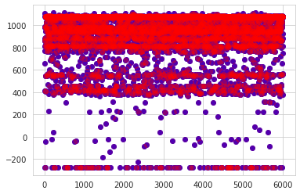

```python
x = range(6013)

plt.plot(x, y_pred_dt, "bo")
plt.plot(x, y_test, "ro", Alpha=0.3)
plt.show()
```